# Results

```r
library(dplyr)
library(knitr)
library(ggplot2)
library(RColorBrewer)
library(smoothCV)
library(data.table)
library(forecast)
library(TTR)
```

## Data Preparation

Set start date to 1 January 2017 and set end date to current system date. Take crude oil price data in the specified period from Yahoo finance:

```r
start <- as.POSIXct("2017-01-01")
end <- as.POSIXct(Sys.Date())

crude_wk <- tidyquant::tq_get("CL=F",
                              from = start, to = end) |>
  mutate(date = as.Date(date, format ="%d/%m/%Y"),
         week = ISOweek::ISOweek(date))|>
  group_by(week) |> slice_tail(n = 1) |>
  select(date, week, close) |> ungroup()

crude_wk |> head() |>
  kable(caption = "First five observations in the dataset")
```

| date | week | close |
| --- | --- | --- |
| 2017-01-06 | 2017-W01 | 53.99 |
| 2017-01-13 | 2017-W02 | 52.37 |
| 2017-01-20 | 2017-W03 | 52.42 |
| 2017-01-27 | 2017-W04 | 53.17 |
| 2017-02-03 | 2017-W05 | 53.83 |
| 2017-02-10 | 2017-W06 | 53.86 |

## Case the First: pre-2019

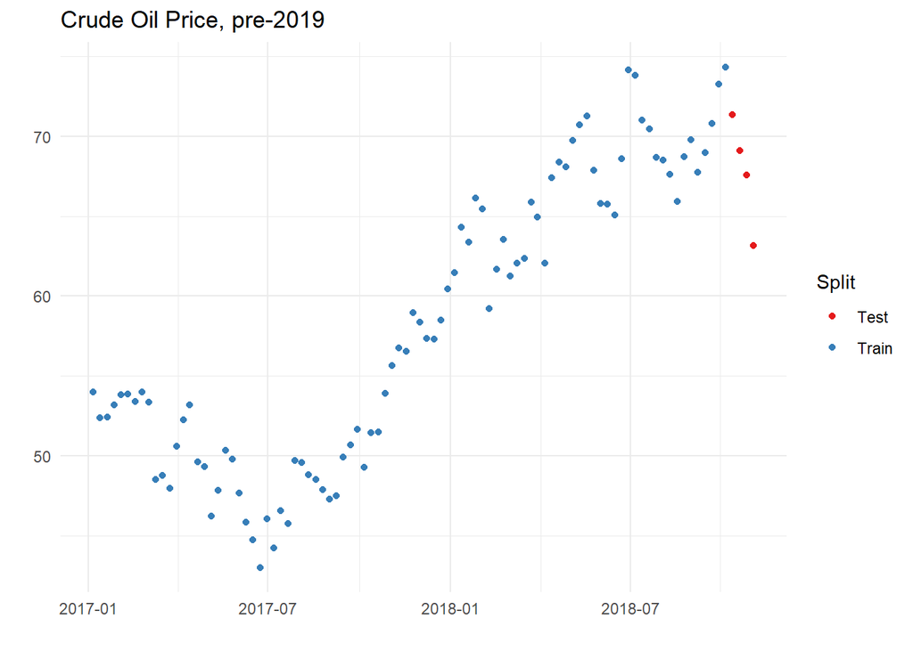

```r
trainset <- crude_wk |>
  filter(date <= as.Date("2018-10-10")) |>
  mutate(Split = "Train")
testset <- crude_wk |>
  filter(date > as.Date("2018-10-10")) |>
  head(4) |> mutate(Split = "Test")

bind_rows(trainset,testset) |>
  ggplot(aes(x = date, y = close,
             color = Split)) +
  geom_point() +
  scale_color_brewer(palette="Set1") +
  theme_minimal() +
  xlab ("") + ylab ("") +
  ggtitle("Crude Oil Price, pre-2019")
```

### Aggregation

#### DES

Now we optimize parameters in the training set through cross-validation, and generate an aggregation table for DES:

```r
resultsDES <- trainset |> select(close) |>
  as.data.table() |>
    fcCV(fullset = _,
         initialn=12,
         folds = 20,
         "DES",
         alphrange=seq(0.1,1,0.1),
         betarange=seq(0.1,1,0.1))

aggregateDES <- resultsDES[[3]] |>
  as_tibble() |>
  group_by(alphrange, betarange) |>
  summarise(mean_MSE=mean(MSE),
            var_MSE=var(MSE),
            mean_MAPE=mean(MAPE),
            var_MAPE=var(MAPE),
            mean_MAE=mean(MAE),
            var_MAE=var(MAE)) |>
  ungroup()

kable(head(aggregateDES),
      col.names = c("$\\alpha$", "$\\beta$",
                    "mean (MSE)", "variance (MSE)",
                    "mean (MAPE)", "variance (MAPE)",
                    "mean (MAE)", "variance (MAE)"))
```

| $\alpha$ | $\beta$ | mean (MSE) | variance (MSE) | mean (MAPE) | variance (MAPE) | mean (MAE) | variance (MAE) |
| --- | --- | --- | --- | --- | --- | --- | --- |
| 0.1 | 0.1 | 24.21855 | 566.60778 | 7.628404 | 19.576321 | 4.257092 | 4.616110 |
| 0.1 | 0.2 | 13.24635 | 184.65251 | 5.132368 | 9.115279 | 2.976714 | 2.631998 |
| 0.1 | 0.3 | 13.03078 | 94.16509 | 5.310935 | 5.911326 | 3.063481 | 1.752101 |
| 0.1 | 0.4 | 13.55964 | 61.36210 | 5.510104 | 3.354422 | 3.185610 | 1.066899 |
| 0.1 | 0.5 | 13.62270 | 97.33306 | 5.298023 | 5.186206 | 3.081098 | 1.671368 |
| 0.1 | 0.6 | 13.83147 | 175.04999 | 5.120507 | 7.628158 | 3.002294 | 2.520726 |

We find parameters that optimize each measure:

```r
params <- aggregateDES |>
  select(mean_MSE, mean_MAPE, mean_MAE,
         var_MSE, var_MAPE, var_MAE)

bestparams <- params |>
  apply(FUN = slice_min, MARGIN = 2,
        .data = aggregateDES, n = 2) |>
  purrr::map2(names(params), select,
            alphrange, betarange)

titles <- names(bestparams) |>
  stringr::str_split(pattern="_")

for(p in seq(length(bestparams))){
  paste("Parameters that minimize",
        titles[[p]][1], "of", titles[[p]][2]) |>
    kable(bestparams[[p]],
          caption = _,
          col.names = c(
            paste(
              {titles[[p]][1] |>
                  R.utils::capitalize()},
              "of", titles[[p]][2]),
            "$\\alpha$", "$\\beta$"))|> print(p)
}
```

Parameters that minimize mean of MSE

| Mean of MSE | $\alpha$ | $\beta$ |
| --- | --- | --- |
| 11.53505 | 0.2 | 0.2 |
| 12.38199 | 0.3 | 0.1 |

Parameters that minimize mean of MAPE

| Mean of MAPE | $\alpha$ | $\beta$ |
| --- | --- | --- |
| 4.787940 | 0.2 | 0.2 |
| 4.790382 | 0.2 | 0.3 |

Parameters that minimize mean of MAE

| Mean of MAE | $\alpha$ | $\beta$ |
| --- | --- | --- |
| 2.826612 | 0.2 | 0.2 |
| 2.850716 | 0.2 | 0.3 |

Parameters that minimize var of MSE

| Var of MSE | $\alpha$ | $\beta$ |
| --- | --- | --- |
| 61.3621 | 0.1 | 0.4 |
| 74.6558 | 0.2 | 0.2 |

Parameters that minimize var of MAPE

| Var of MAPE | $\alpha$ | $\beta$ |
| --- | --- | --- |
| 3.354422 | 0.1 | 0.4 |
| 4.055937 | 0.2 | 0.2 |

Parameters that minimize var of MAE

| Var of MAE | $\alpha$ | $\beta$ |
| --- | --- | --- |
| 1.066899 | 0.1 | 0.4 |
| 1.438596 | 0.2 | 0.2 |

The means of all accuracy measures are all minimized by the parameters $\alpha=0.2$ and $\beta=0.2$, while the variances are all minimized by $\alpha=0.1, \beta=0.4$

#### DMA

```r
resultsDMA <- trainset |> select(close) |>
  as.data.table() |>
    fcCV(initialn=12,
         folds = 20,
         "DMA",
         start = 2,
         end = 6, dist = 1)

aggregateDMA <- resultsDMA[[3]] |>
  as_tibble() |> group_by(M) |>
  summarise(mean_MSE=mean(MSE),
            var_MSE=var(MSE),
            mean_MAPE=mean(MAPE),
            var_MAPE=var(MAPE),
            mean_MAE=mean(MAE),
            var_MAE=var(MAE)) |>
  ungroup()

kable(head(aggregateDMA),
      col.names = c("M",
                    "mean (MSE)", "variance (MSE)",
                    "mean (MAPE)", "variance (MAPE)",
                    "mean (MAE)", "variance (MAE)"))
```

| M | mean (MSE) | variance (MSE) | mean (MAPE) | variance (MAPE) | mean (MAE) | variance (MAE) |
| --- | --- | --- | --- | --- | --- | --- |
| 2 | 25.78217 | 579.8362 | 6.954203 | 16.577070 | 4.084812 | 5.490662 |
| 3 | 30.37991 | 1338.5765 | 7.209714 | 25.216060 | 4.217126 | 9.660735 |
| 4 | 30.57237 | 1369.9274 | 7.312041 | 20.800480 | 4.360110 | 8.813963 |
| 5 | 22.83093 | 538.2283 | 6.547026 | 12.917950 | 3.883035 | 5.390212 |
| 6 | 17.68174 | 398.7954 | 5.672267 | 9.983421 | 3.371007 | 4.064561 |

We find the window size $M$ that optimizes each measure:

```r
params <- aggregateDMA |>
  select(mean_MSE, mean_MAPE, mean_MAE,
         var_MSE, var_MAPE, var_MAE)

bestparams <- params |>
  apply(FUN = slice_min, MARGIN = 2,
        .data = aggregateDMA, n = 2) |>
  purrr::map2(names(params), select,
          M)

titles <- names(bestparams) |>
  stringr::str_split(pattern="_")

for(p in seq(length(bestparams))){
  kable(bestparams[[p]],
        caption = paste("Parameters that minimize",
                        titles[[p]][1], "of",
                        titles[[p]][2]),
        col.names = c(
          paste(
            {titles[[p]][1] |>
                R.utils::capitalize()},
            "of", titles[[p]][2]),
          "M"))|> print(p)
}
```

```
Table: Parameters that minimize mean of MSE

| Mean of MSE|  M|
|-----------:|--:|
|    17.68174|  6|
|    22.83093|  5|


Table: Parameters that minimize mean of MAPE

| Mean of MAPE|  M|
|------------:|--:|
|     5.672267|  6|
|     6.547026|  5|


Table: Parameters that minimize mean of MAE

| Mean of MAE|  M|
|-----------:|--:|
|    3.371007|  6|
|    3.883035|  5|


Table: Parameters that minimize var of MSE

| Var of MSE|  M|
|----------:|--:|
|   398.7954|  6|
|   538.2283|  5|


Table: Parameters that minimize var of MAPE

| Var of MAPE|  M|
|-----------:|--:|
|    9.983421|  6|
|   12.917950|  5|


Table: Parameters that minimize var of MAE

| Var of MAE|  M|
|----------:|--:|
|   4.064561|  6|
|   5.390212|  5|
```

The optimal parameter seems to be $M=6$.

### Comparing baselines with cross-validation

We use two methods as a baseline, optimal DES smoothing and auto.arima:

```r
trainset |> select(close) |>
  stats::HoltWinters(gamma = F)
```

```
Holt-Winters exponential smoothing with trend and without seasonal component.

Call:
stats::HoltWinters(x = select(trainset, close), gamma = F)

Smoothing parameters:
 alpha: 1
 beta : 0.06980948
 gamma: FALSE

Coefficients:
        [,1]
a 74.3399960
b  0.4553176
```

```r
trainset |> select(close) |>
  forecast::auto.arima()
```

```
Series: select(trainset, close)
ARIMA(0,1,0)

sigma^2 = 4.249:  log likelihood = -194.95
AIC=391.9   AICc=391.94   BIC=394.41
```

We find that optimal smoothing uses the parameters $\alpha=1$ and $\beta\approx 0.07$, while auto.arima selects a random walk model where the prediction for future observations is based on the last observation available in the training set.

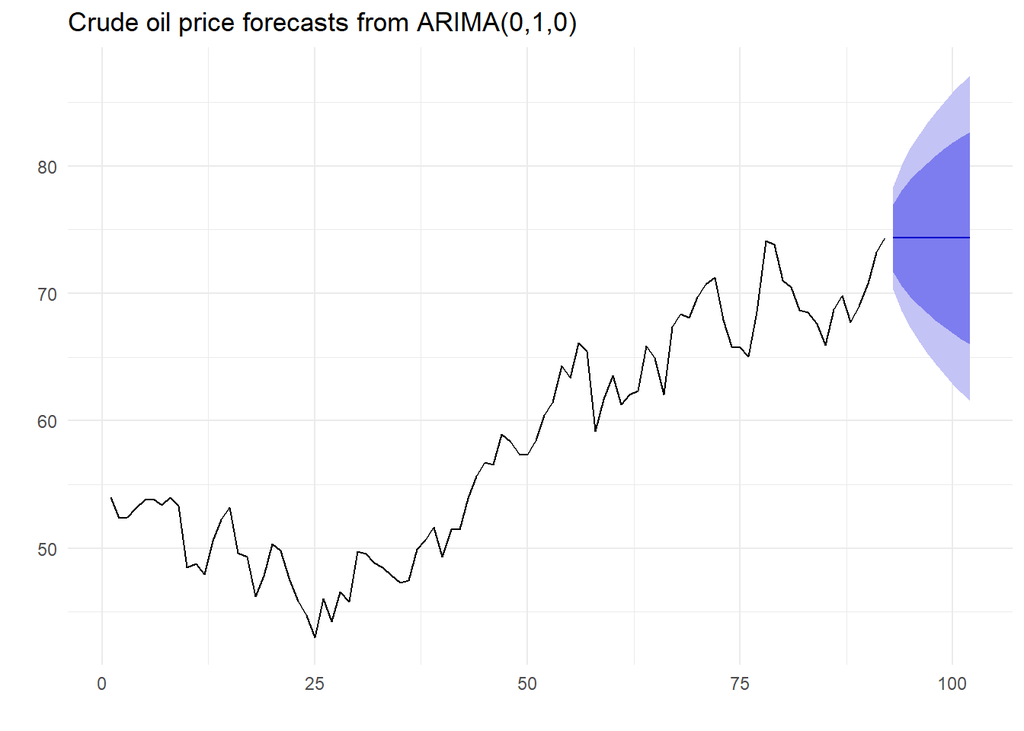

```r
trainset |> select(close) |>
  auto.arima() |> forecast() |>
  autoplot() +
  theme_minimal() +
  xlab("") + ylab("") +
  ggtitle("Crude oil price forecasts from ARIMA(0,1,0)")
```

Now consider accuracy:

```r
kable(
  {
    rbind(
      trainset |> select(close) |>
        stats::HoltWinters(gamma = F) |>
        predict(4) |>
        forecast::accuracy(testset$close),

      trainset |> select(close) |>
        forecast::auto.arima() |>
        predict(4) |> with(pred) |>
        forecast::accuracy(testset$close)
      ) |> as_tibble() |>
      mutate(method = c("Optimal Smoothing",
                    "Auto ARIMA")) |>
      tibble::remove_rownames() |>
      tibble::column_to_rownames(var="method")
    },
  col.names=c("ME", "RMSE" ,"MAE", "MPE", "MAPE"),
  row.names=T
  )
```

|  | ME | RMSE | MAE | MPE | MAPE |
| --- | --- | --- | --- | --- | --- |
| Optimal Smoothing | -7.680791 | 8.440171 | 7.680791 | -11.585867 | 11.585867 |
| Auto ARIMA | -6.542497 | 7.198103 | 6.542497 | -9.870582 | 9.870582 |

```r
kable(
  {
    rbind(
      trainset |> select(close) |>
        stats::HoltWinters(alpha = 0.2, beta = 0.2,
                           gamma = F) |>
        predict(4) |>  accuracy(testset$close),

      trainset |> select(close) |>
        stats::HoltWinters(alpha = 0.1, beta = 0.4,
                           gamma = F) |>
        predict(4) |> accuracy(testset$close),

       accuracy({
        trainset |> select(close) |>
            smoothCV::dma.dt(m = 6,
                             nahead = 4)}[[2]] |>
            select(forc) |> ts(), testset$close)

      ) |> as_tibble() |>
      mutate(method = c("Minimize means (DES)",
                        "Minimize variance (DES)",
                        "Optimal DMA"
                        )) |>
      tibble::remove_rownames() |>
      tibble::column_to_rownames(var="method")
    },
  col.names=c("ME", "RMSE" ,"MAE", "MPE", "MAPE"),
  row.names=T
  )
```

|  | ME | RMSE | MAE | MPE | MAPE |
| --- | --- | --- | --- | --- | --- |
| Minimize means (DES) | -3.580955 | 4.863738 | 3.761038 | -5.512808 | 5.765238 |
| Minimize variance (DES) | -2.113257 | 3.718060 | 2.867624 | -3.328233 | 4.385658 |
| Optimal DMA | -6.741388 | 7.746467 | 6.741388 | -10.218375 | 10.218375 |

DES parameters that minimize variance of error measures performed best, followed by DES parameters that minimize mean of error measures. Both performed better than baseline methods and DMA. DMA at $M=6$ performed worse than auto.arima. Optimal DES performed worst.

## Case the Second: COVID

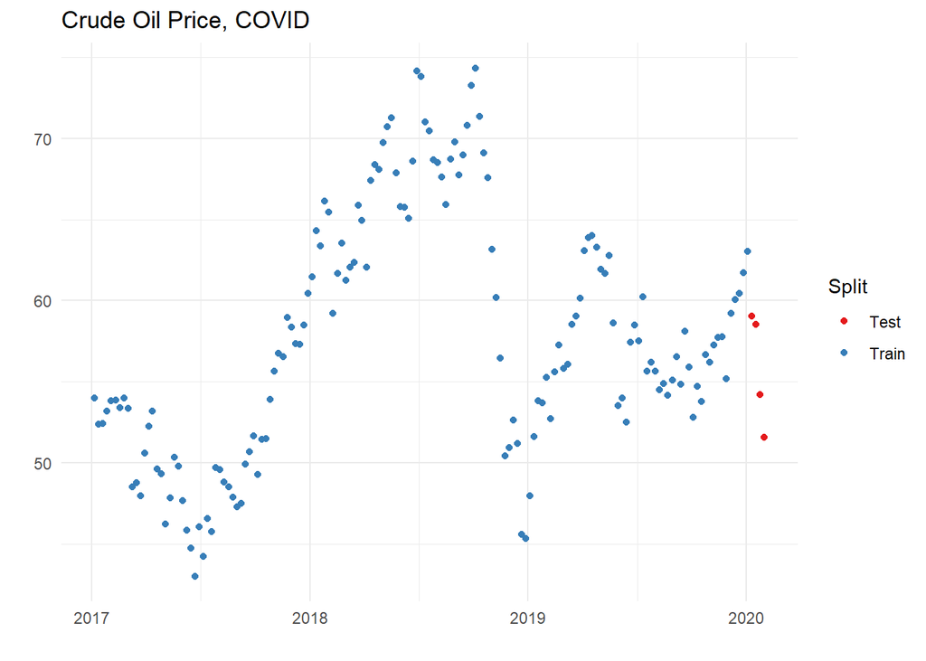

```r
trainset <- crude_wk |>
  filter(date <= as.Date("2020-01-07")) |>
  mutate(Split = "Train")

testset <- crude_wk |>
  filter(date > as.Date("2020-01-07")) |>
  mutate(Split = "Test") |> head(4)

bind_rows(trainset,testset) |>
  ggplot(aes(x = date, y = close,
             color = Split)) +
  geom_point() +
  scale_color_brewer(palette="Set1") +
  theme_minimal() +
  xlab ("") + ylab ("") +
  ggtitle("Crude Oil Price, COVID")
```

Scientists in China announced a new coronavirus in January 7, 2020. We see this leads to a sharp downward trend.

### Aggregation

#### DES

Now we optimize parameters in the training set through cross-validation, and generate an aggregation table for DES:

```r
resultsDES <- trainset |> select(close) |>
  as.data.table() |>
    fcCV(fullset = _,
         initialn= 37,
         folds = 30,
         "DES",
         alphrange=seq(0.1,1,0.1),
         betarange=seq(0.1,1,0.1))

aggregateDES <- resultsDES[[3]] |>
  as_tibble() |>
  group_by(alphrange, betarange) |>
  summarise(mean_MSE=mean(MSE),
            var_MSE=var(MSE),
            mean_MAPE=mean(MAPE),
            var_MAPE=var(MAPE),
            mean_MAE=mean(MAE),
            var_MAE=var(MAE)) |>
  ungroup()

kable(head(aggregateDES),
      col.names = c("$\\alpha$", "$\\beta$",
                    "mean (MSE)", "variance (MSE)",
                    "mean (MAPE)", "variance (MAPE)",
                    "mean (MAE)", "variance (MAE)"))
```

| $\alpha$ | $\beta$ | mean (MSE) | variance (MSE) | mean (MAPE) | variance (MAPE) | mean (MAE) | variance (MAE) |
| --- | --- | --- | --- | --- | --- | --- | --- |
| 0.1 | 0.1 | 42.49662 | 4417.965 | 8.624361 | 55.69392 | 4.991226 | 15.75048 |
| 0.1 | 0.2 | 49.45354 | 4100.300 | 9.623423 | 56.31495 | 5.550512 | 16.29361 |
| 0.1 | 0.3 | 56.69207 | 6037.271 | 10.336899 | 65.88790 | 5.945288 | 18.56582 |
| 0.1 | 0.4 | 56.57830 | 7947.054 | 9.700452 | 78.86570 | 5.583893 | 22.64872 |
| 0.1 | 0.5 | 56.12909 | 7976.801 | 9.350485 | 82.51669 | 5.399909 | 24.07116 |
| 0.1 | 0.6 | 57.35164 | 7962.679 | 9.651215 | 78.44395 | 5.598998 | 22.93820 |

We find parameters that optimize each measure:

```r
params <- aggregateDES |>
  select(mean_MSE, mean_MAPE, mean_MAE,
         var_MSE, var_MAPE, var_MAE)

bestparams <- params |>
  apply(FUN = slice_min, MARGIN = 2,
        .data = aggregateDES, n = 2) |>
  purrr::map2(names(params), select,
            alphrange, betarange)

titles <- names(bestparams) |>
  stringr::str_split(pattern="_")

for(p in seq(length(bestparams))){
  paste("Parameters that minimize",
        titles[[p]][1], "of", titles[[p]][2]) |>
    kable(bestparams[[p]],
          caption = _,
          col.names = c(
            paste(
              {titles[[p]][1] |>
                  R.utils::capitalize()},
              "of", titles[[p]][2]
              )
            ,"$\\alpha$", "$\\beta$"))|> print(p)
}
```

Parameters that minimize mean of MSE

| Mean of MSE | $\alpha$ | $\beta$ |
| --- | --- | --- |
| 10.45230 | 1 | 0.4 |
| 10.63281 | 1 | 0.3 |

Parameters that minimize mean of MAPE

| Mean of MAPE | $\alpha$ | $\beta$ |
| --- | --- | --- |
| 4.181675 | 1 | 0.3 |
| 4.239957 | 1 | 0.2 |

Parameters that minimize mean of MAE

| Mean of MAE | $\alpha$ | $\beta$ |
| --- | --- | --- |
| 2.501439 | 1.0 | 0.3 |
| 2.537278 | 0.9 | 0.4 |

Parameters that minimize var of MSE

| Var of MSE | $\alpha$ | $\beta$ |
| --- | --- | --- |
| 95.69682 | 1.0 | 0.5 |
| 105.82153 | 0.9 | 0.6 |

Parameters that minimize var of MAPE

| Var of MAPE | $\alpha$ | $\beta$ |
| --- | --- | --- |
| 5.278833 | 1 | 0.5 |
| 5.597181 | 1 | 0.4 |

Parameters that minimize var of MAE

| Var of MAE | $\alpha$ | $\beta$ |
| --- | --- | --- |
| 1.741283 | 1.0 | 0.5 |
| 1.968133 | 0.9 | 0.6 |

Mean of MSE is minimized by the parameters $\alpha=1$, $\beta-0.4$. Means of other accuracy measures are minimized by the set of parameters $\alpha=1$ and $\beta=0.3$, while the variance of all measures are minimized by the parameters $\alpha=1$ and $\beta=0.5$.

#### DMA

Meanwhile for DMA:

```r
resultsDMA <- trainset |> select(close) |>
  as.data.table() |>
    fcCV(initialn=37,
         folds = 30,
         "DMA",
         start = 2,
         end = 18, dist = 1)

aggregateDMA <- resultsDMA[[3]] |>
  as_tibble() |> group_by(M) |>
  summarise(mean_MSE=mean(MSE),
            var_MSE=var(MSE),
            mean_MAPE=mean(MAPE),
            var_MAPE=var(MAPE),
            mean_MAE=mean(MAE),
            var_MAE=var(MAE)) |>
  ungroup()

kable(head(aggregateDMA),
      col.names = c("M",
                    "mean (MSE)", "variance (MSE)",
                    "mean (MAPE)", "variance (MAPE)",
                    "mean (MAE)", "variance (MAE)"))
```

| M | mean (MSE) | variance (MSE) | mean (MAPE) | variance (MAPE) | mean (MAE) | variance (MAE) |
| --- | --- | --- | --- | --- | --- | --- |
| 2 | 14.52212 | 260.9809 | 4.983072 | 10.95377 | 2.946375 | 3.297824 |
| 3 | 21.51417 | 1319.2832 | 5.806369 | 20.61085 | 3.455916 | 6.771077 |
| 4 | 31.58821 | 1510.9497 | 7.373402 | 25.99712 | 4.413767 | 9.428453 |
| 5 | 32.64612 | 1347.2257 | 7.672119 | 24.96457 | 4.598170 | 8.964734 |
| 6 | 30.61168 | 1492.6508 | 7.248117 | 30.92910 | 4.307940 | 9.760991 |
| 7 | 34.06831 | 3099.7276 | 7.310130 | 44.76550 | 4.306901 | 13.366880 |

We find the window size $M$ that optimizes each measure:

```r
params <- aggregateDMA |>
  select(mean_MSE, mean_MAPE, mean_MAE,
         var_MSE, var_MAPE, var_MAE)

bestparams <- params |>
  apply(FUN = slice_min, MARGIN = 2,
        .data = aggregateDMA, n = 2) |>
  purrr::map2(names(params), select,
          M)

titles <- names(bestparams) |>
  stringr::str_split(pattern="_")

for(p in seq(length(bestparams))){
  kable(bestparams[[p]],
        caption = paste("Parameters that minimize",
                        titles[[p]][1], "of",
                        titles[[p]][2]),
        col.names = c(
          paste(
            {titles[[p]][1] |>
                R.utils::capitalize()},
            "of", titles[[p]][2]),
          "M"))|> print(p)
}
```

Parameters that minimize mean of MSE

| Mean of MSE | M |
| --- | --- |
| 14.52212 | 2 |
| 21.51417 | 3 |

Parameters that minimize mean of MAPE

| Mean of MAPE | M |
| --- | --- |
| 4.983072 | 2 |
| 5.806369 | 3 |

Parameters that minimize mean of MAE

| Mean of MAE | M |
| --- | --- |
| 2.946375 | 2 |
| 3.455916 | 3 |

Parameters that minimize var of MSE

| Var of MSE | M |
| --- | --- |
| 260.9809 | 2 |
| 1319.2832 | 3 |

Parameters that minimize var of MAPE

| Var of MAPE | M |
| --- | --- |
| 10.95377 | 2 |
| 20.61085 | 3 |

Parameters that minimize var of MAE

| Var of MAE | M |
| --- | --- |
| 3.297824 | 2 |
| 6.771077 | 3 |

The optimal parameter seems to be $M=2$.

### Comparing baselines with cross-validation

We use two methods as a baseline:

```r
trainset |> select(close) |>
  auto.arima()
```

```
Series: select(trainset, close)
ARIMA(0,1,0)

sigma^2 = 4.878:  log likelihood = -344.96
AIC=691.92   AICc=691.95   BIC=694.97
```

```r
trainset |> select(close) |>
  stats::HoltWinters(gamma=F)
```

```
Holt-Winters exponential smoothing with trend and without seasonal component.

Call:
stats::HoltWinters(x = select(trainset, close), gamma = F)

Smoothing parameters:
 alpha: 1
 beta : 0.06321651
 gamma: FALSE

Coefficients:
       [,1]
a 63.049999
b  0.352854
```

As before, auto.arima picked a random walk model. Moreover optimal smoothing picked the parameters $\alpha=1$ and $\beta\approx 0.06$

```r
kable(
  {
    rbind(
      trainset |> select(close) |>
        stats::HoltWinters(gamma = F) |>
        predict(4) |>
        forecast::accuracy(testset$close),

      trainset |> select(close) |>
        forecast::auto.arima() |>
        predict(4) |> with(pred) |>
        forecast::accuracy(testset$close)
      ) |> as_tibble() |>
      mutate(method = c("Optimal Smoothing",
                    "Auto ARIMA")) |>
      tibble::remove_rownames() |>
      tibble::column_to_rownames(var="method")
    },
  col.names=c("ME", "RMSE" ,"MAE", "MPE", "MAPE"),
  row.names=T
  )
```

|  | ME | RMSE | MAE | MPE | MAPE |
| --- | --- | --- | --- | --- | --- |
| Optimal Smoothing | -8.099633 | 8.818481 | 8.099633 | -14.90619 | 14.90619 |
| Auto ARIMA | -7.217498 | 7.857159 | 7.217498 | -13.28268 | 13.28268 |

Compare with the DES smoothing parameters provided by cross-validation and DMA.

```r
kable(
  {
    rbind(
      trainset |> select(close) |>
        stats::HoltWinters(alpha = 1, beta = 0.4,
                           gamma = F) |>
        predict(4) |>
        forecast::accuracy(testset$close),

      trainset |> select(close) |>
        stats::HoltWinters(alpha = 1, beta = 0.3,
                           gamma = F) |>
        predict(4) |>
        forecast::accuracy(testset$close),
      trainset |> select(close) |>
        stats::HoltWinters(alpha = 1, beta = 0.5,
                           gamma = F) |>
        predict(4) |>
        forecast::accuracy(testset$close),

      accuracy({
        trainset |> select(close) |>
            smoothCV::dma.dt(m = 2,
                             nahead = 4)}[[2]] |>
            select(forc) |> ts(), testset$close)


      ) |> as_tibble() |>
      mutate(method = c("Minimize mean MSE",
                        "Minimize mean MAPE and MAE",
                        "Minimize variances",
                        "Optimal DMA"
                        )) |>
      tibble::remove_rownames() |>
      tibble::column_to_rownames(var="method")
    },
  col.names=c("ME", "RMSE" ,"MAE", "MPE", "MAPE"),
  row.names=T
  )
```

|  | ME | RMSE | MAE | MPE | MAPE |
| --- | --- | --- | --- | --- | --- |
| Minimize mean MSE | -9.999082 | 10.89145 | 9.999082 | -18.40198 | 18.40198 |
| Minimize mean MAPE and MAE | -9.752956 | 10.62267 | 9.752956 | -17.94900 | 17.94900 |
| Minimize variances | -10.157459 | 11.06442 | 10.157459 | -18.69346 | 18.69346 |
| Optimal DMA | -10.467500 | 11.40527 | 10.467500 | -19.26461 | 19.26461 |

Cross-validation performed worse than the baseline.

## Case the Third: COVID Recovery

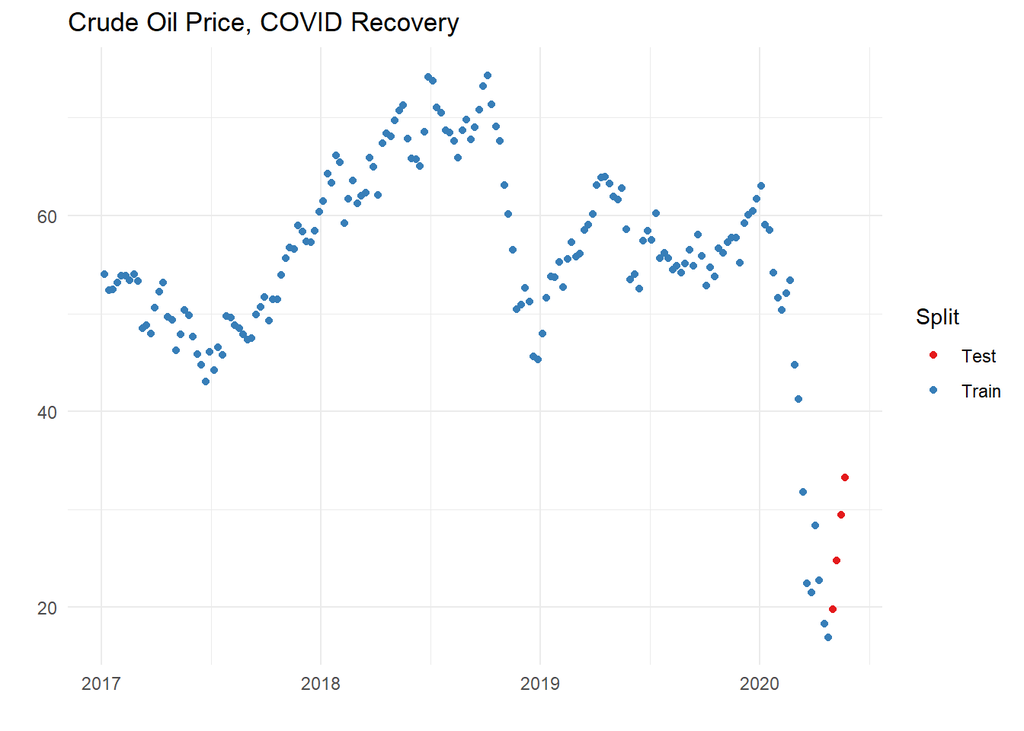

```r
trainset <- crude_wk |>
  filter(date <= as.Date("2020-04-27")) |>
  mutate(Split = "Train")
testset <- crude_wk |>
  filter(date > as.Date("2020-04-27")) |>
  head(4) |> mutate(Split = "Test")

bind_rows(trainset,testset) |>
ggplot(aes(x = date, y = close,
             color = Split)) +
  geom_point() +
  scale_color_brewer(palette="Set1") +
  theme_minimal() +
  xlab ("") + ylab ("") +
  ggtitle("Crude Oil Price, COVID Recovery")
```

Saudi Arabia and Russia agreed to cut production in April 2020. However, the effect of these cuts on WTI futures price were lagged - supply needed time to adjust. Therefore, oil prices only began to rise in May. This is another area where we can experiment with smoothing.

### Aggregation

#### DES

Now we optimize parameters in the training set through cross-validation, and generate an aggregation table:

```r
resultsDES <- trainset |> select(close) |>
  as.data.table() |>
    fcCV(fullset = _,
         initialn=53,
         folds = 30,
         "DES",
         alphrange=seq(0.1,1,0.1),
         betarange=seq(0.1,1,0.1))

aggregateDES <- resultsDES[[3]] |>
  as_tibble() |>
  group_by(alphrange, betarange) |>
  summarise(mean_MSE=mean(MSE),
            var_MSE=var(MSE),
            mean_MAPE=mean(MAPE),
            var_MAPE=var(MAPE),
            mean_MAE=mean(MAE),
            var_MAE=var(MAE)) |>
  ungroup()

kable(head(aggregateDES),
      col.names = c("$\\alpha$", "$\\beta$",
                    "mean (MSE)", "variance (MSE)",
                    "mean (MAPE)", "variance (MAPE)",
                    "mean (MAE)", "variance (MAE)"))
```

| $\alpha$ | $\beta$ | mean (MSE) | variance (MSE) | mean (MAPE) | variance (MAPE) | mean (MAE) | variance (MAE) |
| --- | --- | --- | --- | --- | --- | --- | --- |
| 0.1 | 0.1 | 79.58787 | 22409.63 | 14.95391 | 584.7713 | 6.288107 | 36.01184 |
| 0.1 | 0.2 | 84.09288 | 19081.28 | 15.81616 | 474.2507 | 6.980449 | 30.88001 |
| 0.1 | 0.3 | 91.22610 | 20100.20 | 16.18864 | 393.1239 | 7.457094 | 30.60582 |
| 0.1 | 0.4 | 81.53257 | 14612.62 | 14.03686 | 268.6871 | 6.822230 | 30.31566 |
| 0.1 | 0.5 | 73.28523 | 11113.82 | 12.71666 | 211.2417 | 6.372895 | 28.06219 |
| 0.1 | 0.6 | 73.02217 | 10746.59 | 12.86009 | 197.2549 | 6.504965 | 25.75470 |

We find parameters that optimize each measure:

```r
params <- aggregateDES |>
  select(mean_MSE, mean_MAPE, mean_MAE,
         var_MSE, var_MAPE, var_MAE)

bestparams <- params |>
  apply(FUN = slice_min, MARGIN = 2,
        .data = aggregateDES, n = 2) |>
  purrr::map2(names(params), select,
            alphrange, betarange)

titles <- names(bestparams) |>
  stringr::str_split(pattern="_")

for(p in seq(length(bestparams))){
  paste("Parameters that minimize",
        titles[[p]][1], "of", titles[[p]][2]) |>
    kable(bestparams[[p]], caption = _,
          col.names = c(
            paste(
              {titles[[p]][1] |> R.utils::capitalize()},
              "of", titles[[p]][2]
              )
            ,"$\\alpha$", "$\\beta$"))|> print(p)
}
```

Parameters that minimize mean of MSE

| Mean of MSE | $\alpha$ | $\beta$ |
| --- | --- | --- |
| 21.38116 | 1 | 0.5 |
| 21.77953 | 1 | 0.6 |

Parameters that minimize mean of MAPE

| Mean of MAPE | $\alpha$ | $\beta$ |
| --- | --- | --- |
| 7.250763 | 1.0 | 0.7 |
| 7.366123 | 0.9 | 0.9 |

Parameters that minimize mean of MAE

| Mean of MAE | $\alpha$ | $\beta$ |
| --- | --- | --- |
| 3.407517 | 1 | 0.3 |
| 3.416105 | 1 | 0.4 |

Parameters that minimize var of MSE

| Var of MSE | $\alpha$ | $\beta$ |
| --- | --- | --- |
| 796.0093 | 1 | 0.6 |
| 815.0225 | 1 | 0.7 |

Parameters that minimize var of MAPE

| Var of MAPE | $\alpha$ | $\beta$ |
| --- | --- | --- |
| 34.91936 | 1.0 | 0.9 |
| 40.65303 | 0.9 | 1.0 |

Parameters that minimize var of MAE

| Var of MAE | $\alpha$ | $\beta$ |
| --- | --- | --- |
| 5.631918 | 1 | 0.6 |
| 5.977887 | 1 | 0.5 |

#### DMA

Meanwhile for DMA:

```r
resultsDMA <- trainset |> select(close) |>
  as.data.table() |>
    fcCV(initialn=53,
         folds = 30,
         "DMA",
         start = 2,
         end = 26, dist = 1)

aggregateDMA <- resultsDMA[[3]] |>
  as_tibble() |> group_by(M) |>
  summarise(mean_MSE=mean(MSE),
            var_MSE=var(MSE),
            mean_MAPE=mean(MAPE),
            var_MAPE=var(MAPE),
            mean_MAE=mean(MAE),
            var_MAE=var(MAE)) |>
  ungroup()

kable(head(aggregateDMA),
      col.names = c("M",
                    "mean (MSE)", "variance (MSE)",
                    "mean (MAPE)", "variance (MAPE)",
                    "mean (MAE)", "variance (MAE)"))
```

| M | mean (MSE) | variance (MSE) | mean (MAPE) | variance (MAPE) | mean (MAE) | variance (MAE) |
| --- | --- | --- | --- | --- | --- | --- |
| 2 | 30.00932 | 2363.821 | 9.030868 | 198.6425 | 3.920375 | 11.08079 |
| 3 | 50.60450 | 9959.806 | 11.816413 | 442.1122 | 4.861814 | 22.03833 |
| 4 | 56.37461 | 6538.577 | 12.823202 | 335.2772 | 5.726048 | 18.65502 |
| 5 | 49.71152 | 3263.001 | 12.035050 | 199.3164 | 5.664199 | 13.16143 |
| 6 | 41.54493 | 2459.919 | 10.287268 | 111.6493 | 5.073461 | 11.58342 |
| 7 | 45.80808 | 4530.937 | 9.992543 | 129.5905 | 5.043030 | 16.22658 |

We find the window size $M$ that optimizes each measure:

```r
params <- aggregateDMA |>
  select(mean_MSE, mean_MAPE, mean_MAE,
         var_MSE, var_MAPE, var_MAE)

bestparams <- params |>
  apply(FUN = slice_min, MARGIN = 2,
        .data = aggregateDMA, n = 2) |>
  purrr::map2(names(params), select,
          M)

titles <- names(bestparams) |>
  stringr::str_split(pattern="_")

for(p in seq(length(bestparams))){
  kable(bestparams[[p]],
        caption = paste("Parameters that minimize",
                        titles[[p]][1], "of",
                        titles[[p]][2]),
        col.names = c(
          paste(
            {titles[[p]][1] |>
                R.utils::capitalize()},
            "of", titles[[p]][2]),
          "M"))|> print(p)
}
```

Parameters that minimize mean of MSE

| Mean of MSE | M |
| --- | --- |
| 30.00932 | 2 |
| 41.54493 | 6 |

Parameters that minimize mean of MAPE

| Mean of MAPE | M |
| --- | --- |
| 9.030868 | 2 |
| 9.992543 | 7 |

Parameters that minimize mean of MAE

| Mean of MAE | M |
| --- | --- |
| 3.920375 | 2 |
| 4.861814 | 3 |

Parameters that minimize var of MSE

| Var of MSE | M |
| --- | --- |
| 2363.821 | 2 |
| 2459.919 | 6 |

Parameters that minimize var of MAPE

| Var of MAPE | M |
| --- | --- |
| 111.6493 | 6 |
| 129.5905 | 7 |

Parameters that minimize var of MAE

| Var of MAE | M |
| --- | --- |
| 11.08079 | 2 |
| 11.58342 | 6 |

The optimal parameter seems to be $M=2$ or 6.

### Comparison

```r
trainset |> select(close) |>
  auto.arima()
```

```
Series: select(trainset, close)
ARIMA(0,1,1)

Coefficients:
         ma1
      0.1731
s.e.  0.0760

sigma^2 = 6.666:  log likelihood = -406.71
AIC=817.42   AICc=817.49   BIC=823.71
```

```r
trainset |> select(close) |>
  stats::HoltWinters(gamma=F)
```

```
Holt-Winters exponential smoothing with trend and without seasonal component.

Call:
stats::HoltWinters(x = select(trainset, close), gamma = F)

Smoothing parameters:
 alpha: 1
 beta : 0.08341341
 gamma: FALSE

Coefficients:
       [,1]
a 16.940001
b -2.062455
```

auto.arima picked a MA(1) model. Moreover optimal smoothing picked the parameters $\alpha=1$ and $\beta\approx 0.08$

```r
kable(
  {
    rbind(
      trainset |> select(close) |>
        stats::HoltWinters(gamma = F) |>
        predict(4) |>
        forecast::accuracy(testset$close),

      trainset |> select(close) |>
        forecast::auto.arima() |>
        predict(4) |> with(pred) |>
        forecast::accuracy(testset$close),

      {trainset |> select(close) |>
          naive(4) |>
          forecast::accuracy(testset$close)
        }[2,-(6:7)]

      ) |> as_tibble() |>
      mutate(method = c("Optimal Smoothing",
                    "Auto ARIMA",
                    "Naive")) |>
      tibble::remove_rownames() |>
      tibble::column_to_rownames(var="method")
    },
  col.names=c("ME", "RMSE" ,"MAE", "MPE", "MAPE"),
  row.names=T
  )
```

|  | ME | RMSE | MAE | MPE | MAPE |
| --- | --- | --- | --- | --- | --- |
| Optimal Smoothing | 15.016138 | 16.72024 | 15.016138 | 52.57841 | 52.57841 |
| Auto ARIMA | 9.990698 | 11.19486 | 9.990698 | 34.85109 | 34.85109 |
| Naive | 9.859999 | 11.07838 | 9.859999 | 34.34453 | 34.34453 |

Compare with the DES smoothing parameters provided by cross-validation.

```r
kable(
  {
    rbind(
      trainset |> select(close) |>
        stats::HoltWinters(alpha = 1, beta = 0.5,
                           gamma = F) |>
        predict(4) |>
        forecast::accuracy(testset$close),

      trainset |> select(close) |>
        stats::HoltWinters(alpha = 1, beta = 0.7,
                           gamma = F) |>
        predict(4) |>
        forecast::accuracy(testset$close),

      trainset |> select(close) |>
        stats::HoltWinters(alpha = 1, beta = 0.3,
                           gamma = F) |>
        predict(4) |>
        forecast::accuracy(testset$close),

      trainset |> select(close) |>
        stats::HoltWinters(alpha = 1, beta = 0.6,
                           gamma = F) |>
        predict(4) |>
        forecast::accuracy(testset$close),

      trainset |> select(close) |>
        stats::HoltWinters(alpha = 1, beta = 0.9,
                           gamma = F) |>
        predict(4) |>
        forecast::accuracy(testset$close),

       accuracy({
        trainset |> select(close) |>
            smoothCV::dma.dt(m = 2,
                             nahead = 4)}[[2]] |>
            select(forc) |> ts(), testset$close)

      ) |> as_tibble() |>
      mutate(method = c("Minimize mean MSE",
                        "Minimize mean MAPE",
                        "Minimize mean MAE",
                        "Minimize var MSE and MAE",
                        "Minimize var MAPE",
                        "DMA"
                        )) |>
      tibble::remove_rownames() |>
      tibble::column_to_rownames(var="method")
    },
  col.names=c("ME", "RMSE" ,"MAE", "MPE", "MAPE"),
  row.names=T
  )
```

|  | ME | RMSE | MAE | MPE | MAPE |
| --- | --- | --- | --- | --- | --- |
| Minimize mean MSE | 15.70008 | 17.46892 | 15.70008 | 54.99705 | 54.99705 |
| Minimize mean MAPE | 15.16792 | 16.88639 | 15.16792 | 53.11516 | 53.11516 |
| Minimize mean MAE | 16.28543 | 18.10972 | 16.28543 | 57.06707 | 57.06707 |
| Minimize var MSE and MAE | 15.48580 | 17.23435 | 15.48580 | 54.23928 | 54.23928 |
| Minimize var MAPE | 13.97337 | 15.57887 | 13.97337 | 48.89082 | 48.89082 |
| DMA | 17.92500 | 19.75378 | 17.92500 | 63.13329 | 63.13329 |

## Case the Fourth: Vaccines

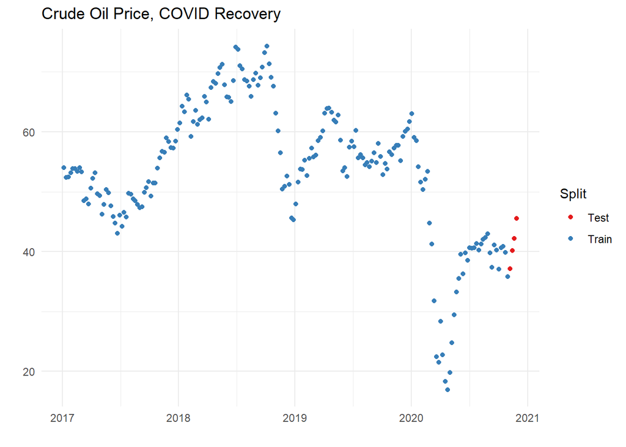

```r
trainset <- crude_wk |>
  filter(date <= as.Date("2020-11-01")) |>
  mutate(Split = "Train")
testset <- crude_wk |>
  filter(date > as.Date("2020-11-01")) |>
  head(4) |> mutate(Split = "Test")
bind_rows(trainset,testset) |>
  ggplot(aes(x = date, y = close,
             color = Split)) +
  geom_point() +
  scale_color_brewer(palette="Set1") +
  theme_minimal() +
  xlab ("") + ylab ("") +
  ggtitle("Crude Oil Price, COVID Recovery")
```

Pfizer announced a COVID-19 vaccine in November 8, 2020, leading to a sharp rise in oil futures price.

### Aggregation

#### DES

Now we optimize parameters in the training set through cross-validation, and generate an aggregation table:

```r
resultsDES <- trainset |> select(close) |>
  as.data.table() |>
    fcCV(fullset = _,
         initialn=80,
         folds = 30,
         "DES",
         alphrange=seq(0.1,1,0.1),
         betarange=seq(0.1,1,0.1))

aggregateDES <- resultsDES[[3]] |>
  as_tibble() |>
  group_by(alphrange, betarange) |>
  summarise(mean_MSE=mean(MSE),
            var_MSE=var(MSE),
            mean_MAPE=mean(MAPE),
            var_MAPE=var(MAPE),
            mean_MAE=mean(MAE),
            var_MAE=var(MAE)) |>
  ungroup()

kable(head(aggregateDES),
      col.names = c("$\\alpha$", "$\\beta$",
                    "mean (MSE)", "variance (MSE)",
                    "mean (MAPE)", "variance (MAPE)",
                    "mean (MAE)", "variance (MAE)"))
```

| $\alpha$ | $\beta$ | mean (MSE) | variance (MSE) | mean (MAPE) | variance (MAPE) | mean (MAE) | variance (MAE) |
| --- | --- | --- | --- | --- | --- | --- | --- |
| 0.1 | 0.1 | 112.0335 | 22611.52 | 20.21526 | 557.5587 | 7.992590 | 42.13256 |
| 0.1 | 0.2 | 137.3531 | 33536.82 | 22.49059 | 536.0381 | 9.215490 | 45.98062 |
| 0.1 | 0.3 | 173.6070 | 59419.65 | 24.85633 | 584.0476 | 10.352482 | 58.05164 |
| 0.1 | 0.4 | 176.4699 | 70676.68 | 24.09048 | 547.5882 | 10.143880 | 63.05238 |
| 0.1 | 0.5 | 162.5202 | 62639.72 | 22.40748 | 515.8486 | 9.474089 | 61.59452 |
| 0.1 | 0.6 | 160.4935 | 58306.55 | 22.60598 | 496.7887 | 9.611769 | 55.87709 |

We find parameters that optimize each measure:

```r
params <- aggregateDES |>
  select(mean_MSE, mean_MAPE, mean_MAE,
         var_MSE, var_MAPE, var_MAE)

bestparams <- params |>
  apply(FUN = slice_min, MARGIN = 2,
        .data = aggregateDES, n = 2) |>
  purrr::map2(names(params), select,
            alphrange, betarange)

titles <- names(bestparams) |>
  stringr::str_split(pattern="_")

for(p in seq(length(bestparams))){
  paste("Parameters that minimize",
        titles[[p]][1], "of", titles[[p]][2]) |>
    kable(bestparams[[p]], caption = _,
          col.names = c(
            paste(
              {titles[[p]][1] |> R.utils::capitalize()},
              "of", titles[[p]][2]
              )
            ,"$\\alpha$", "$\\beta$"))|> print(p)
}
```

Parameters that minimize mean of MSE

| Mean of MSE | $\alpha$ | $\beta$ |
| --- | --- | --- |
| 42.16412 | 0.8 | 0.1 |
| 42.18678 | 0.7 | 0.1 |

Parameters that minimize mean of MAPE

| Mean of MAPE | $\alpha$ | $\beta$ |
| --- | --- | --- |
| 10.59267 | 0.7 | 0.1 |
| 10.61026 | 0.6 | 0.1 |

Parameters that minimize mean of MAE

| Mean of MAE | $\alpha$ | $\beta$ |
| --- | --- | --- |
| 4.576704 | 0.8 | 0.1 |
| 4.579595 | 0.7 | 0.1 |

Parameters that minimize var of MSE

| Var of MSE | $\alpha$ | $\beta$ |
| --- | --- | --- |
| 3925.311 | 0.4 | 0.5 |
| 4012.273 | 0.4 | 0.4 |

Parameters that minimize var of MAPE

| Var of MAPE | $\alpha$ | $\beta$ |
| --- | --- | --- |
| 151.4943 | 0.7 | 0.1 |
| 152.7987 | 0.6 | 0.1 |

Parameters that minimize var of MAE

| Var of MAE | $\alpha$ | $\beta$ |
| --- | --- | --- |
| 13.75327 | 0.5 | 0.3 |
| 13.79796 | 0.5 | 0.4 |

Means of MSE and MAE are minimized by the parameters $\alpha=0.8$ and $\beta=0.1$, mean and variance of MAPE are minimized by the parameters $\alpha=0.7$ and $\beta=0.1$. Variance of MSE is minimized by $\alpha=0.4$ and $\beta=0.5$ and variance of MAE is minimized by $\alpha=0.5$ and $\beta=0.3$.

#### DMA

Meanwhile for DMA:

```r
resultsDMA <- trainset |> select(close) |>
  as.data.table() |>
    fcCV(initialn=80,
         folds = 30,
         "DMA",
         start = 2,
         end = 39, dist = 1)

aggregateDMA <- resultsDMA[[3]] |>
  as_tibble() |> group_by(M) |>
  summarise(mean_MSE=mean(MSE),
            var_MSE=var(MSE),
            mean_MAPE=mean(MAPE),
            var_MAPE=var(MAPE),
            mean_MAE=mean(MAE),
            var_MAE=var(MAE)) |>
  ungroup()

kable(head(aggregateDMA),
      col.names = c("M",
                    "mean (MSE)", "variance (MSE)",
                    "mean (MAPE)", "variance (MAPE)",
                    "mean (MAE)", "variance (MAE)"))
```

| M | mean (MSE) | variance (MSE) | mean (MAPE) | variance (MAPE) | mean (MAE) | variance (MAE) |
| --- | --- | --- | --- | --- | --- | --- |
| 2 | 92.18967 | 28846.416 | 16.67993 | 609.9523 | 6.447333 | 36.23488 |
| 3 | 59.79302 | 9141.685 | 12.72939 | 273.0482 | 5.407204 | 21.84371 |
| 4 | 51.42964 | 3319.927 | 12.67614 | 145.9223 | 5.522441 | 12.77438 |
| 5 | 52.79086 | 5113.880 | 12.82427 | 183.4710 | 5.476253 | 15.49009 |
| 6 | 64.42980 | 10191.813 | 13.69626 | 262.7885 | 5.789843 | 22.84463 |
| 7 | 70.11533 | 11712.865 | 14.12517 | 268.7640 | 5.983437 | 26.25276 |

We find the window size $M$ that optimizes each measure:

```r
params <- aggregateDMA |>
  select(mean_MSE, mean_MAPE, mean_MAE,
         var_MSE, var_MAPE, var_MAE)

bestparams <- params |>
  apply(FUN = slice_min, MARGIN = 2,
        .data = aggregateDMA, n = 2) |>
  purrr::map2(names(params), select,
          M)

titles <- names(bestparams) |>
  stringr::str_split(pattern="_")

for(p in seq(length(bestparams))){
  kable(bestparams[[p]],
        caption = paste("Parameters that minimize",
                        titles[[p]][1], "of",
                        titles[[p]][2]),
        col.names = c(
          paste(
            {titles[[p]][1] |>
                R.utils::capitalize()},
            "of", titles[[p]][2]),
          "M"))|> print(p)
}
```

Parameters that minimize mean of MSE

| Mean of MSE | M |
| --- | --- |
| 51.42964 | 4 |
| 52.79086 | 5 |

Parameters that minimize mean of MAPE

| Mean of MAPE | M |
| --- | --- |
| 12.67614 | 4 |
| 12.72939 | 3 |

Parameters that minimize mean of MAE

| Mean of MAE | M |
| --- | --- |
| 5.407204 | 3 |
| 5.476253 | 5 |

Parameters that minimize var of MSE

| Var of MSE | M |
| --- | --- |
| 3319.927 | 4 |
| 5113.880 | 5 |

Parameters that minimize var of MAPE

| Var of MAPE | M |
| --- | --- |
| 145.9223 | 4 |
| 183.4710 | 5 |

Parameters that minimize var of MAE

| Var of MAE | M |
| --- | --- |
| 12.77438 | 4 |
| 15.49009 | 5 |

The optimal parameter seems to be $M=4$ or 3.

### Comparison

We use three methods as a baseline:

```r
trainset |> select(close) |>
  auto.arima()
```

```
Series: select(trainset, close)
ARIMA(0,1,1)

Coefficients:
         ma1
      0.1627
s.e.  0.0694

sigma^2 = 6.731:  log likelihood = -471.61
AIC=947.21   AICc=947.27   BIC=953.8
```

```r
trainset |> select(close) |>
  stats::HoltWinters(gamma=F)
```

```
Holt-Winters exponential smoothing with trend and without seasonal component.

Call:
stats::HoltWinters(x = select(trainset, close), gamma = F)

Smoothing parameters:
 alpha: 1
 beta : 0.0557182
 gamma: FALSE

Coefficients:
        [,1]
a 35.7900010
b -0.2503346
```

auto.arima chooses a MA(1) model. We also choose the naive method and optimal DES

```r
kable(
  {
    rbind(
      trainset |> select(close) |>
        stats::HoltWinters(gamma = F) |>
        predict(4) |>
        forecast::accuracy(testset$close),

      trainset |> select(close) |>
        forecast::auto.arima() |>
        predict(4) |> with(pred) |>
        forecast::accuracy(testset$close),

      {trainset |> select(close) |>
          naive(4) |>
          forecast::accuracy(testset$close)
        }[2,-(6:7)]

      ) |> as_tibble() |>
      mutate(method = c("Optimal Smoothing",
                    "Auto ARIMA",
                    "Naive")) |>
      tibble::remove_rownames() |>
      tibble::column_to_rownames(var="method")
    },
  col.names=c("ME", "RMSE" ,"MAE", "MPE", "MAPE"),
  row.names=T
  )
```

|  | ME | RMSE | MAE | MPE | MAPE |
| --- | --- | --- | --- | --- | --- |
| Optimal Smoothing | 6.073336 | 6.927046 | 6.073336 | 14.20847 | 14.20847 |
| Auto ARIMA | 6.082360 | 6.805415 | 6.082360 | 14.28079 | 14.28079 |
| Naive | 5.447499 | 6.244503 | 5.447499 | 12.73280 | 12.73280 |

```r
kable(
  {
    rbind(
      trainset |> select(close) |>
        stats::HoltWinters(alpha = 0.8, beta = 0.1,
                           gamma = F) |>
        predict(4) |>
        forecast::accuracy(testset$close),

      trainset |> select(close) |>
        stats::HoltWinters(alpha = 0.7, beta = 0.1,
                           gamma = F) |>
        predict(4) |>
        forecast::accuracy(testset$close),

      trainset |> select(close) |>
        stats::HoltWinters(alpha = 0.4, beta = 0.5,
                           gamma = F) |>
        predict(4) |>
        forecast::accuracy(testset$close),

      trainset |> select(close) |>
        stats::HoltWinters(alpha = 0.5, beta = 0.3,
                           gamma = F) |>
        predict(4) |>
        forecast::accuracy(testset$close),

       accuracy({
        trainset |> select(close) |>
            smoothCV::dma.dt(m = 4,
                             nahead = 4)}[[2]] |>
            select(forc) |> ts(), testset$close),

       accuracy({
        trainset |> select(close) |>
            smoothCV::dma.dt(m = 3,
                             nahead = 4)}[[2]] |>
            select(forc) |> ts(), testset$close)

      ) |> as_tibble() |>
      mutate(method = c("Minimize mean MSE and MAE",
                        "Minimize mean and var MAPE",
                        "Minimize var MSE",
                        "Minimize var MAE",
                        "DMA (1)",
                        "DMA(2)"
                        )) |>
      tibble::remove_rownames() |>
      tibble::column_to_rownames(var="method")
    },
  col.names=c("ME", "RMSE" ,"MAE", "MPE", "MAPE"),
  row.names=T
  )
```

|  | ME | RMSE | MAE | MPE | MAPE |
| --- | --- | --- | --- | --- | --- |
| Minimize mean MSE and MAE | 5.289692 | 6.270778 | 5.289692 | 12.291150 | 12.291150 |
| Minimize mean and var MAPE | 4.725506 | 5.773491 | 4.725506 | 10.924638 | 10.924638 |
| Minimize var MSE | 4.340666 | 5.709481 | 4.660910 | 9.915592 | 10.777853 |
| Minimize var MAE | 4.747951 | 6.006911 | 4.844808 | 10.913969 | 11.174760 |
| DMA (1) | 2.759167 | 4.283003 | 3.578647 | 6.137524 | 8.343985 |
| DMA(2) | 5.049721 | 6.378638 | 5.141944 | 11.610586 | 11.858898 |

Cross-validation performed better than baseline. Surprisingly, DMA performed best.